# Praca Domowa 3

Agata Makarewicz

15 04 2021

### Wstęp

Naszym zadaniem będzie analiza wyjaśniająca decyzję modelu uczenia maszynowego (w jaki sposób poszczególne zmienne na nią wpływają). Będą to wyjaśnienia lokalne, dla pojedynczych predykcji.

Skorzystamy ze zbioru danych `phones` zawierającego informacje o cechach różnych telefonów dostępnych na rynku. Rozważamy problem regresji (chcemy przewidzieć zmienną `price`) przy wykorzystaniu lasu losowego zaimplementowany w pakiecie `ranger`. Analizy dokonamy na poniższych obserwacjach:

|  | name | brand | back_camera_mpix | front_camera_mpix | battery_mAh | ram_gb | flash_gb | diag | height_px | width_px | price |
| --- | --- | --- | --- | --- | --- | --- | --- | --- | --- | --- | --- |
| 1 | Xiaomi Mi 10T 6+128GB | Xiaomi | 64 | 20 | 5000 | 6 | 128 | 6.67 | 2400 | 1080 | 1999 |
| 59 | OPPO A91 | OPPO | 48 | 16 | 4025 | 8 | 128 | 6.40 | 2400 | 1080 | 999 |
| 63 | Apple iPhone 11 64GB | Apple | 12 | 12 | 3110 | 4 | 64 | 6.10 | 1792 | 828 | 3149 |

Zbiór posiada ok. 11% obserwacji z brakującymi wartościami w niektórych kolumnach, na potrzeby tego zadania (tworzenia modelu) rekordy te zostaną pominięte. Pominiemy również zmienną `name`, która jest w oczywisty sposób skorelowana ze zmienną `brand` oraz praktycznie unikalna dla każdej obserwacji (328/368 wartości unikalnych po usunięciu braków).

### Model & explainer

```r
model <- ranger(price~., data = data[,-1], num.trees = 50)
explainer <- DALEX::explain(model = model, data = data[,-c(1,11)], y = data$price)
```

### Wyliczenie predykcji dla wybranej obserwacji

```r
predict(model, data[1,])$predictions
```

```
## [1] 2588.7
```

### Dekompozycja predykcji

#### Ceteris Paribus dla wybranej obserwacji

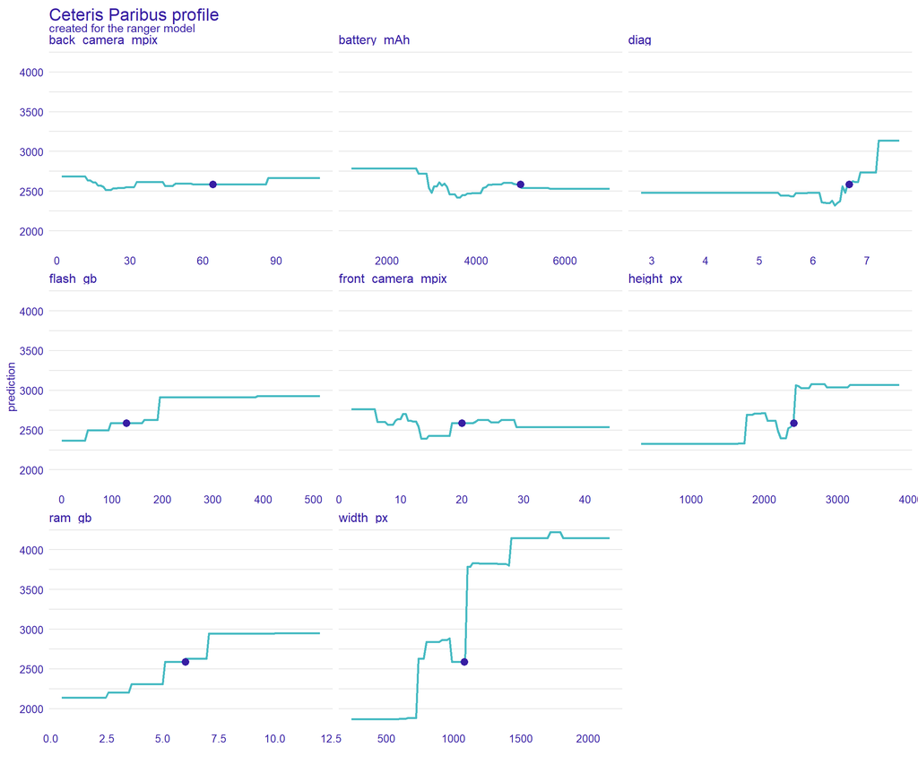

Na powyższym profilu możemy zaobserwować jak zmienia się nasza predykcja dla wybranej (pierwszej) obserwacji przy zwiększaniu wartości poszczególnych zmiennych. W przypadku zmiennych dotyczących pamięci - `flash_gb` oraz `ram_gb` - obserwujemy wzrost predykcji aż do pewnych wartości (odpowiednio 200 oraz 7.5 GB), powyżej których stabilizuje się. Może być to spowodowane tym, że mamy nieliczne telefony o większej pamięci na rynku (outliery wykryte w czasie EDA) i zwyczajnie nie ma zapotrzebowania na aż tak duże pojemności. Dość niestandardową obserwacją jest to, że obserwujemy “delikatnie” negatywny wpływ zmiennych `front_camera_mpix`, `back_camera_mpix` oraz `battry_mAh`, w przypadku których wzrost wartości powoduje wahania/lekki spadek predykcji. Być może jest to specyficzna sytuacja, akurat dla tej obserwacji - dziwne, żeby lepszy aparat czy bateria powodowały spadek ceny telefonu. Jeśli chodzi o wymiary telefonu - wszystkie 3 zmienne mają pozytywny wpływ na cenę telefonu, poza drobnym spadkiem w okolicy wymiarów 1000x2000, co jest dość niespodziwane. Dla przekątnej wyraźny pozytywny wpływ obserwujemy dopiero gdy jej wartość przekracza 6. Jest to zgodne z wcześniejszymy analizami, oraz ogólną sytuacją na rynku - ekrany takiej wielkości zwykle powodują spory przeskok cenowy (w stosunku do np. 5.5), ciekawe jest jednak to że wzrost predykcji przy wzroście szerokości ekranu jest znacznie większy, niż dla innych zmiennych opisujących rozmiar. Może to być związane z wysoką korelacją pomiędzy nimi, zaobserwowaną podczas EDA.